# Missing, delayed, and old: A status review of ESA recovery plans Jacob Malcom, Defenders of Wildlife Sept. 2016

# Abstract

Recovery planning is an essential part of implementing the U.S. Endangered Species Act (ESA) because explicit planning helps identify and address the key threats to listed species. Despite the importance of recovery planning, it is generally acknowledged that reaching a “final” plan takes far longer than the goal of 2-1/2 years from the time of listing. But the extent of planning (number of species with recovery plans) and time required for planning has not been evaluated for over a decade. Using data from all domestic ESA-listed species, we quantify basic characteristics of ESA recovery planning. We show that 1/4 of listed species lack recovery plans; the average recovery plan has taken >5 years to be developed after listing; and the recovery plans that have been written are nearly 20 years old on average. These results are not unexpected for agencies that have seen dwindling budgets and more species to protect, but they highlight the need to improve recovery planning so that ESA-listed species can benefit. Defenders proposes that these challenges can be addressed, in part, by moving to [web-based, dynamic recovery plans](https://defend-esc-dev.org/dynamic-recovery/) that can improve efficiency in plan development and improve effectiveness by providing timely information.

# Introduction

The U.S. Endangered Species Act (ESA) requires the Fish and Wildlife Service (FWS) and National Marine Fisheries Service (NMFS; collectively, the Services) to develop plans to guide the recovery of listed species, unless doing so is not warranted (e.g., for foreign listed species). Recovery plans have evoloved significantly over the years, as has recovery planning guidance the Services use. The Services’ [1994 recovery planning guidance](http://www.nmfs.noaa.gov/pr/pdfs/fr/fr59-16024.pdf) stated that “the Services will…develop recovery plans within 2-1/2 years after final listing.” But we know a persistent problem is that recovery planning often takes far longer than that. While this problem is a “generally accepted” fact, there is very little quantitative information that can adequately describe the scope of the challenge.

Using the data scraped from FWS’s [ECOS website](http://ecos.fws.gov)<sup>1</sup>, we sought to answer answer several outstanding questions about ESA recovery planning. How many species have final recovery plans, and how has that changed over the last 35 years?<sup>2</sup> What is the average or median time from listing to an original final recovery plan?<sup>3</sup> What proportion of species have plans completed within the 2.5-year time-frame? How has the time required for a recovery plan changed over the past >40 years? How old are recovery plans as of 2016?<sup>4</sup> Is there variation in time-to-recovery plan among FWS regions or between the Services? We show that both the extent of recovery plan coverage and the time required for recovery plan development, finalization, and revision are falling short of expectations. This analysis should provide a solid reason for the Services, and FWS in particular, to critically evaluate how recovery planning is done. (NMFS recently undertook a [public review of their recovery program](http://www.nmfs.noaa.gov/pr/recovery/#2016%20National%20Recovery%20Program%20Review) and is implementing changes.)

1: The raw data scraped from ECOS cannot be used directly, so we undertook several data cleaning and management steps to prepare it for analysis (Appendix A). In addition to the Appendix, the raw Rmarkdown file that generated this working paper can be reviewed for the entire analysis.

2: We focus on domestic and transboundary species because foreign listed species will rarely if ever have recovery plans.

3: We only include species with recovery plans that are the *original* final plan in the current analysis of time-to-plan: including species with revisions (which may come many years later) in these calculations would artificially inflate the time-to-plan. Unfortunately, ECOS rarely includes the original plan or the date of the original final plan, so we can’t yet estimate the time-to-plan for species that have revisions.

4: In contrast to the time-to-plan estimates, we *do include* all species with either original or revised plans for estimating plan age as of 2016 because the most-recent time is known and the age estimate is unbiased.

# Species with and without plans

The first question we need to address is, *How many domestic listed species have plans, and how has that number changed through time?* The answer to this question is important to interpreting time-to-plan statistics and figures because those analyses only include species with final recovery plans.<sup>5</sup>

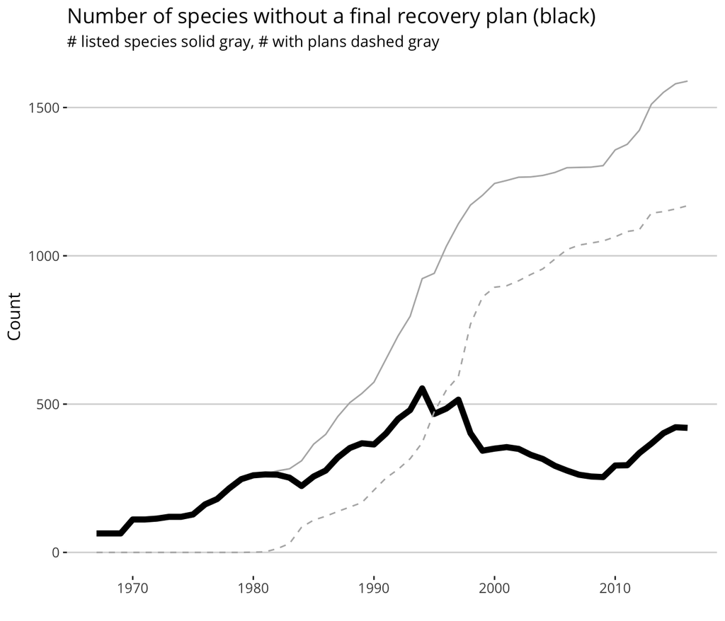

Click figure to enlarge

This pattern highlights the challenge of interpreting the time-to-plan figures because of the right censored data. The 420 species without final or revised plans today effectively have a time-to-plan of infinity, so estimates of the mean / median will be biased low. Because of the stationarity problem, there’s no reliable way to correct the bias.

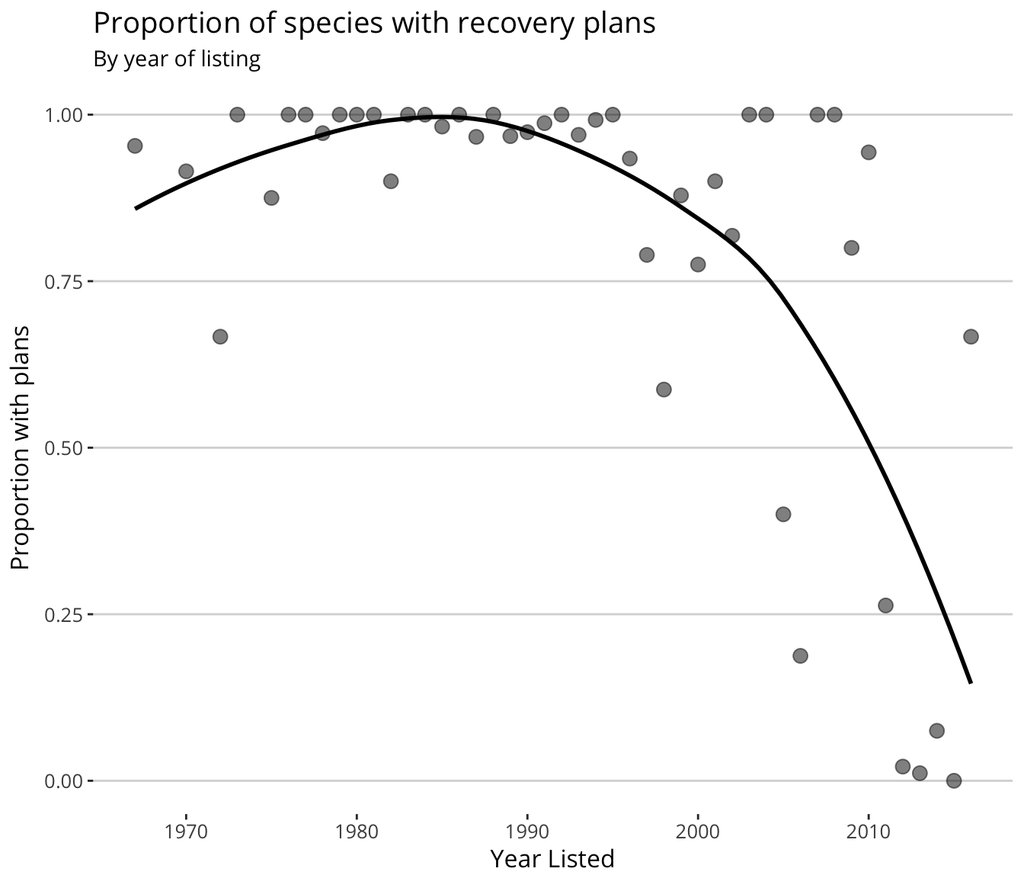

Click figure to enlarge

### Number of plans through time

Given the variation of time-to-plan over the decades, it would be interesting to know when species got their plans and when plans - which may be multi-species - were written.

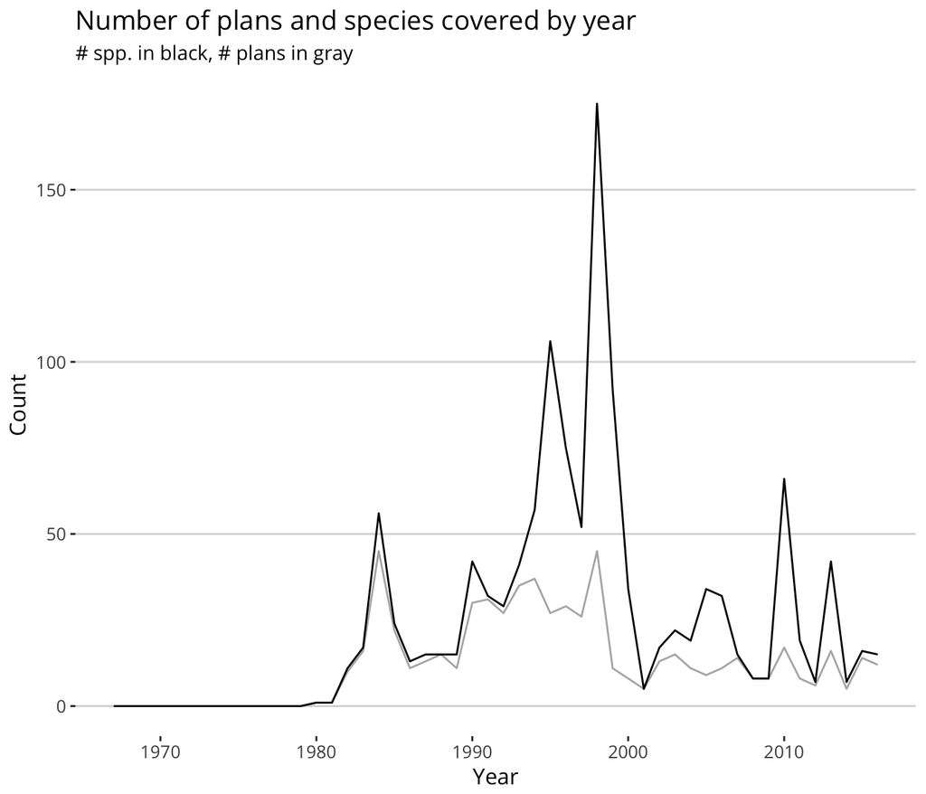

Click figure to enlarge

In the mid- to late-1990s a lot of species got recovery plans, in large part because of the increase in multi-species plans, which have costs (specificity) and benefits (some planning). We also know that many plans from this time are insufficient by current standards. Since the [Society for Conservation Biology recovery planning review](https://www.nceas.ucsb.edu/recovery/publications.html) that concluded in 2002, recovery plans have become much more thorough, which may contribute to the lower rate of plan completion in the past 15 years.

5: This is “right censored” data, akin to the challenge of estimating the effects of a treatment on survival when individuals are still alive at the end of the experiment. While there are ways to estimate an “expected” values for right-censored data, those methods require making the questionable assumption that the same underlying process generates the data ([stationarity](https://en.wikipedia.org/wiki/Stationary_process)). We should suspect that variation in presidential administrations, congresses, and career staff at national, regional, and local levels have significant effects on the process that generates final recovery plans within some time-frame. Rather than make the almost certainly invalid assumption, we will instead look at how the number of species without plans has changed through time.

Return to text

# Time-to-plan

As noted in the **Introduction**, the time to develop and finalize recovery plans is known to be “too long.” *What does the data say about how long recovery planning takes?* (As discussed in footnote 3 of the Introduction, these analyses use only species that have a final plan, but not those with a revised plan.)

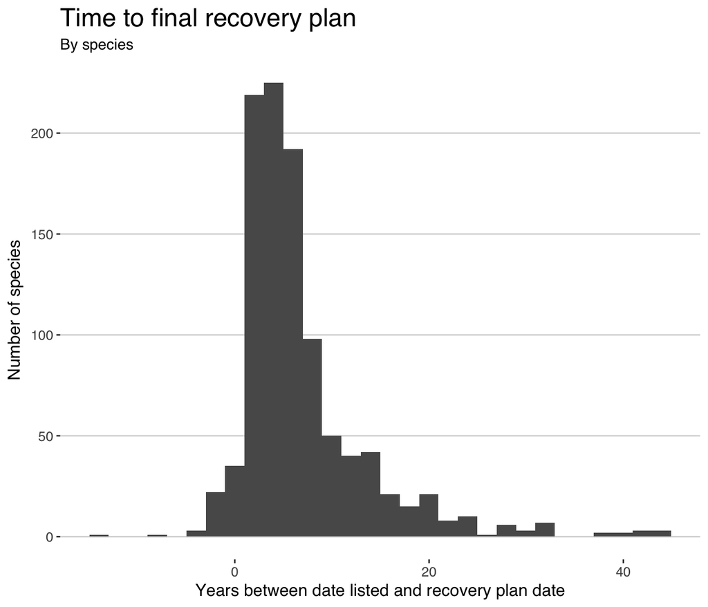

Click figure to enlarge

|  | n | min | median | mean | max |
| --- | --- | --- | --- | --- | --- |
| Listed Date | 1034 | 1967-03-11 | 1992-05-13 | 1990-06-28 | 2013-09-19 |
| Plan Date | 1034 | 1980-03-17 | 1997-07-29 | 1997-05-31 | 2016-08-05 |
| Years Elapsed | 1034 | -13.5 | 5.1 | 7 | 44 |

Another question about time-to-plans is, *What percentage of recovery plans are completed in X years?* For example, how often do the Services meet their goal of 2.5 years from listing to final recovery plan?

[interactive chart not shown]

Click figure to enlarge

## Time-to-plan over the years

Bearing in mind the issue of right-censored data, we can now ask, *How has the time it takes to write and finalize a recovery plan changed over the years?*

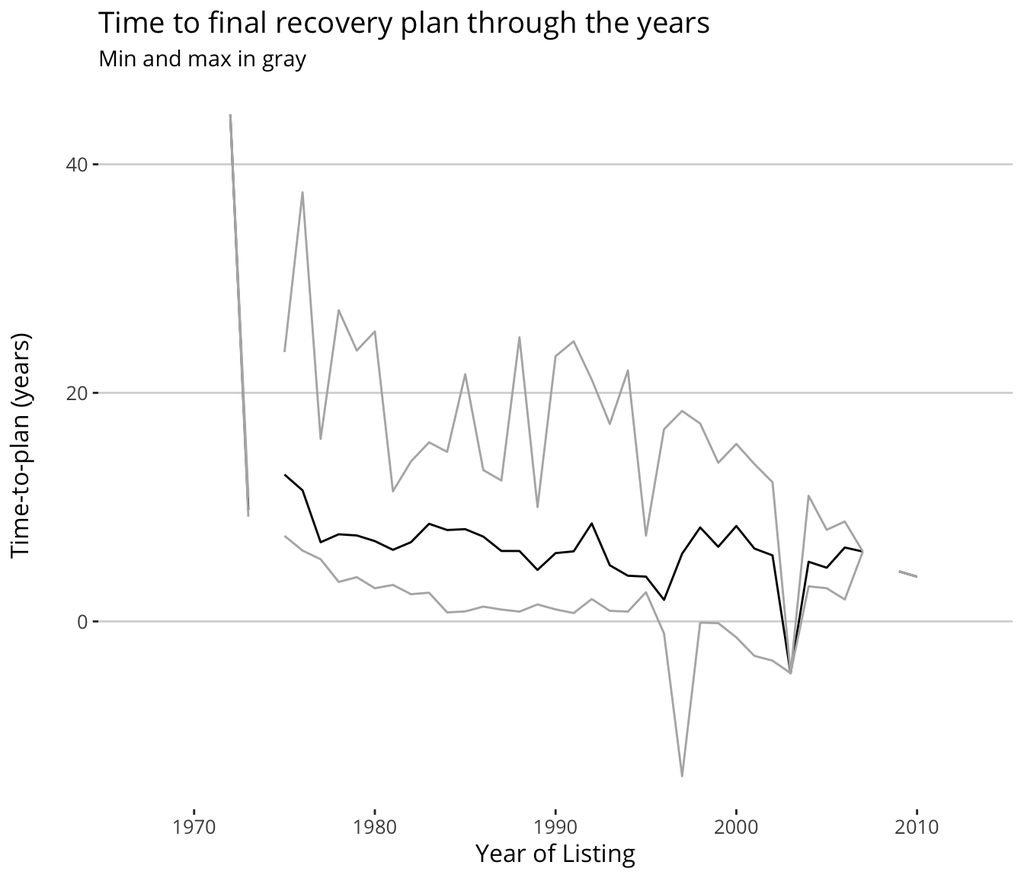

Click figure to enlarge

# Plan ages

Another challenge of recovery planning is the difficulty of updating plans: revisions require extensive work by planning teams and *Federal Register* notices and potential revisions to a revision draft. But what we (collectively) know about a species changes rapidly, from basic biological research, to the types of management that can help or hinder recovery, and many topics in-between. This begs the question, *What is the distribution of recovery plan ages?* (As described in footnote 4 of the Introduction, these analyses include all species with final plans, whether original or revised.)

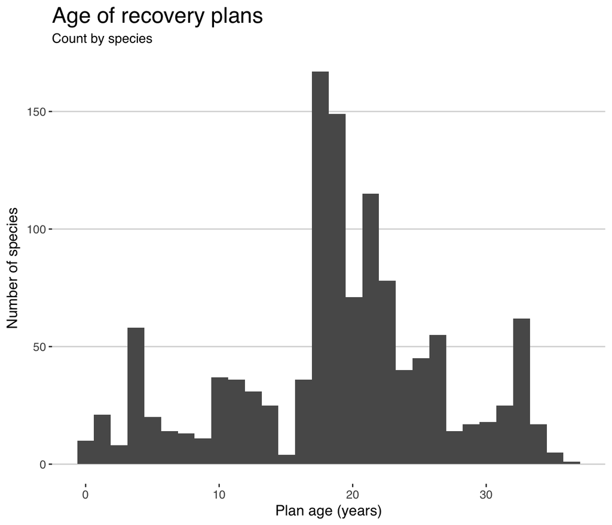

Click figure to enlarge

With a median age of 19.1 years, most recovery plans are quite old - if plans were people, they could vote. The distribution reflects the pattern of plans-through-time even without considering the 135 plans that have been or are being revised. As with the time-to-plan, we can use a dynamic percentile plot to quickly find out the proportion of species’ plans that are less than X years old:

[interactive chart not shown]

Click figure to enlarge

Only 16% of species have plans that are < 10 years old; 10% of species have plans that are >30 years old. These numbers highlight a dire need for some way to improve how recovery plans are updated. Many species are part of multi-species plans, and so have the same age for the individual plans. We can plot the ages of plans, rather than of species’ plan ages:

[interactive chart not shown]

Click figure to enlarge

This view of the data suggests a slightly worse picture. The median age of *plans* is 22 years and 17% of plans are > 30 years old; the difference on the high end is because more older plans are single-species than the average-age plan.

# Plans by region and agency

Because of the high degree of independence among FWS regions and differences between FWS and NMFS, it may be instructive to break down recovery planning along those lines. *Which regions / agency have finalized the highest numbers and proportions of plans?*

Distribution of plans among FWS regions and NMFS.

| Region_Agency | With_Plans | Without_Plans | Prop_Plans |
| --- | --- | --- | --- |
| 1 | 407 | 124 | 0.766 |
| 2 | 128 | 32 | 0.800 |
| 3 | 36 | 10 | 0.783 |
| 4 | 321 | 48 | 0.870 |
| 5 | 40 | 5 | 0.889 |
| 6 | 58 | 3 | 0.951 |
| 7 | 6 | 2 | 0.750 |
| 8 | 231 | 65 | 0.780 |
| NMFS | 43 | 34 | 0.558 |

How does the variation in time-to-plan break down by region/agency?

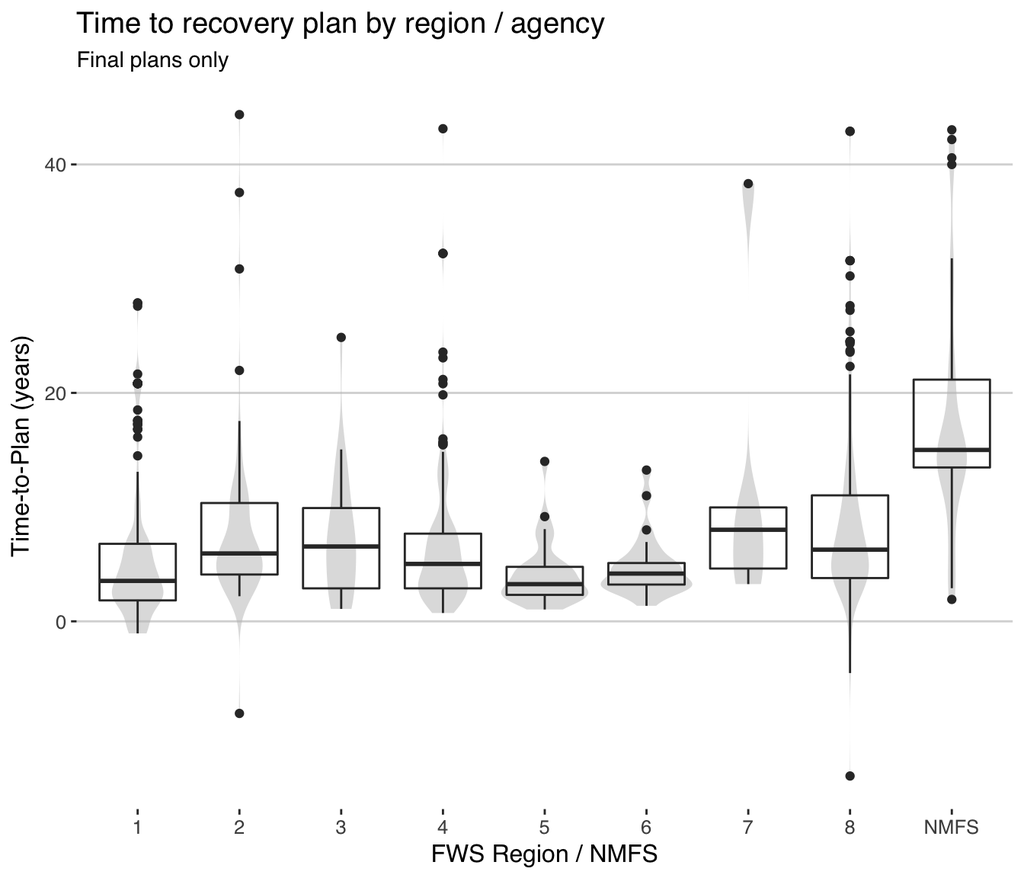

Click figure to enlarge

Time for NMFS is both high (median) and highly variable relative to FWS regions. Regions 4 and 8, which encompass many species, do not take as long recovery planning as I would have thought.

# Discussion

Recovery planning was incorporated in the 1978 amendments to the ESA because of the realization that planning should improve conservation outcomes. Significant progress has been made improving the quality of recovery plans: contemporary plans are far more detailed and science-based than many older plans. But the handful of species that benefit from “modern” recovery plans are overshadowed by the shortcomings identified here.

# Appendix A *Data cleaning*

While the code for all of the plots and tables can be easily viewed by examining the Rmarkdown document for this vignette, we provide the data cleaning (commented out) here for ease of viewing from the HTML document.

```r
# combo <- dplyr::left_join(recovery_plan_table,
#                           species_info_table,
#                           by = "Species")
# names(combo)[1] <- "Rec_Plan_Date"
# combo$Rec_Plan_Date <- as_date(combo$Rec_Plan_Date)
# names(combo)[4] <- "Plan_Status"
# names(combo)[8] <- "Date_Cur_Status"
# combo$Date_Cur_Status <- as_date(combo$Date_Cur_Status)
# combo$Cur_Status_To_Plan <- as.numeric(combo$Rec_Plan_Date - combo$Date_Cur_Status)
# combo <- distinct(combo, Species, `Where Listed`, .keep_all = TRUE)
# combo$Status <- sub(combo$Status,
#                     pattern = 'displayListingStatus\\(\\"',
#                     replacement = '')
# combo$Status <- sub(combo$Status,
#                     pattern = '\\"\\)',
#                     replacement = '')
# combo <- filter(combo, Status == "Threatened" | Status == "Endangered")
#
# # Next, the join with the 'big' ECOS species table to get original listing dates
# recplan_spp <- left_join(combo, ecos_all_spp, by = c("Species" = "Scientific_Name"))
# recplan_spp <- filter(recplan_spp, US_Foreign %in% c("US", "US/Foreign"))
# recplan_spp <- filter(recplan_spp,
#                       Federal_Listing_Status %in% c("Endangered", "Threatened"))
# recplan_spp <- select(recplan_spp, Rec_Plan_Date, Title, Plan_Status,
#                       Species, Status, Date_Cur_Status, Lead_Region,
#                       Cur_Status_To_Plan, First_Listed, Species_Group,
#                       US_Foreign, Where_Listed)
# recplan_spp <- distinct(recplan_spp, Species, Where_Listed, .keep_all = TRUE)
# recplan_spp$Elapsed <- as.numeric(recplan_spp$Rec_Plan_Date - recplan_spp$First_Listed)
# recplan_spp$Elapsed_Years <- recplan_spp$Elapsed / 365
#
# # Looks like I'm missing records for ~50 species compared to what the BoxScore
# # provides (http://ecos.fws.gov/ecp0/reports/box-score-report)...wait, no, the
# # footnote on that page says "active plans," so both draft and final.
# final_plans <- filter(recplan_spp, recplan_spp$Plan_Status == "Final")
# with_plan <- filter(recplan_spp,
#                     recplan_spp$Plan_Status != "Outline",
#                     recplan_spp$Plan_Status != "Conservation Strategy",
#                     recplan_spp$Plan_Status != "Exempt")
#
# ###############
# # Also need the complement of the previous, a data.frame of listed species,
# # with NAs for listed species lacking plans. Note that the 1593 I get here is
# # the same as what BoxScore indicates today.
# listed <- filter(ecos_all_spp,
#                  Federal_Listing_Status %in% c("Endangered", "Threatened"))
# listed <- filter(listed, US_Foreign %in% c("US", "US/Foreign"))
#
# listed <- left_join(listed, combo, by = c("Scientific_Name" = "Species"))
# listed <- distinct(listed, Scientific_Name, Where_Listed, .keep_all = TRUE)
# listed <- select(listed, -`Plan Action Status`, -Doc_Link, -Status, -`Lead Region`,
#                   -`Where Listed`)
# listed$Year_Listed <- year(listed$First_Listed)
# listed$Year_Plan <- year(listed$Rec_Plan_Date)
#
# no_plan <- filter(listed, is.na(listed$Year_Plan))
```